# Normal Distribution: Assessing Normality

Wednesday, March 04, 2026 @ 04:36 PM

## Are data from a normal distribution?

Many statistical tests require data to be drawn from a normal distribution. Researchers may also interested in determining whether some variable of interest is normally distributed. For example, Belgian scholar [Adolphe Quetelet](http://www-groups.dcs.st-and.ac.uk/history/Biographies/Quetelet.html) (1796-1874) had a hypothesis that the natural distribution of human heights is a bell curve (i.e., normal distribution).

We can never *prove* that unknown data come from a normal distribution, but we can compare the data to the theoretical model and determine whether the data deviates too far to be considered approximately normal.

Let’s first investigate this using height data gathered by another famous statistician. [Francis Galton](http://www-history.mcs.st-andrews.ac.uk/Biographies/Galton.html) (1822-1911) investigated the relationship between the heights of parents and their offspring. Some of his data can be found in galtonparentheights.csv.

## The Galton Height Data (Parents)

```r
head(parent_hts)
```

```
  FamilyID Father Mother
1        1   78.5   67.0
2        2   75.5   66.5
3        3   75.0   64.0
4        4   75.0   64.0
5        5   75.0   58.5
6        6   74.0   68.0
```

This time we will calculate mean and standard deviation using base `R` methods. These sample values will serve as parameter estimates for our theoretical model and plots.

```r
xbar <- mean(parent_hts$Mother)
s    <- sd(parent_hts$Mother)
```

## Density Plot

Does the data density match a theoretical normal density plot?

Create a density plot of the data and superimpose a theoretical normal model on the same axes. Do the data deviate too far?

```r
ggplot(parent_hts, aes(x = Mother)) +
  geom_density() +
  stat_function(
    fun = dnorm,
    args = list(xbar, s),   # scaled to the data's mean and sd
    linetype = "dashed",
    color = "orange"
  ) +
  theme_minimal()
```

We are using `dnorm` because the density plot estimates \(f(x)\).

## Questions

- Is the data distribution unimodal like the theoretical normal distribution?
- Is the data distribution skewed (left or right) or approximately symmetric?
- How well does the distribution of data match the theoretical curve in the tails? Where does it it deviate?
- Is there a pattern to any data deviations from the theoretical normal curve, or do they appear to be random?
- In general, we are most concerned about moderate or strong skew, large outliers (particularly if they only occur in one tail), and distinct bi- or multi-modality.

## Data vs. Theoretical

How would you answer the questions for this plot?

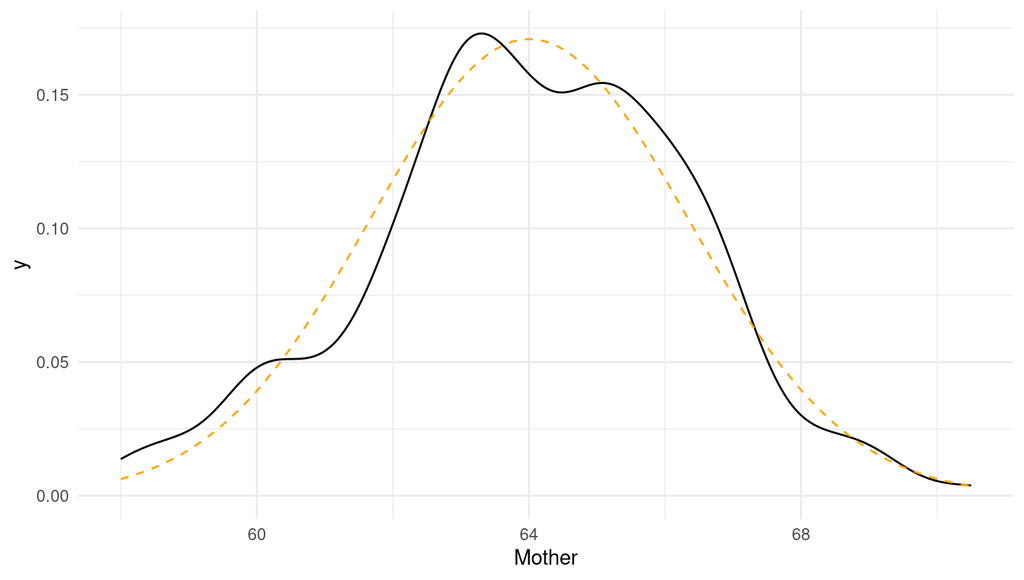

## Theoretical Normal Quantiles

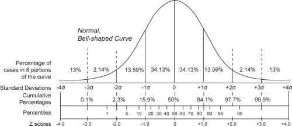

Notice the placement of the percentiles (also called quantiles) on the theoretical normal distribution. If we know \(\mu\) and \(\sigma\) we can determine the locations of the quantiles. For example, look at the *deciles*, which are the 10th, 20th, 30th, etc. percentiles.

This will allow us to construct a normal quantile-quantile plot, also known as a QQ plot or normal probability plot.

Do the data deciles match the theoretical normal deciles?

```r
deciles <- c(0.1, 0.2, 0.3, 0.4, 0.5, 0.6, 0.7, 0.8, 0.9)
tibble(percentile = deciles * 100,
       data       = quantile(parent_hts$Mother, deciles),
       theory     = qnorm(deciles, xbar, s))
```

```
# A tibble: 9 × 3
  percentile  data theory
       <dbl> <dbl>  <dbl>
1         10  61     61.0
2         20  62     62.0
3         30  63     62.8
4         40  63.5   63.4
5         50  64     64.0
6         60  65     64.6
7         70  65.3   65.2
8         80  66     66.0
9         90  67     67.0
```

## Plot of Data vs. Theoretical Deciles

Do the decile pairs deviate too far from the straight line?

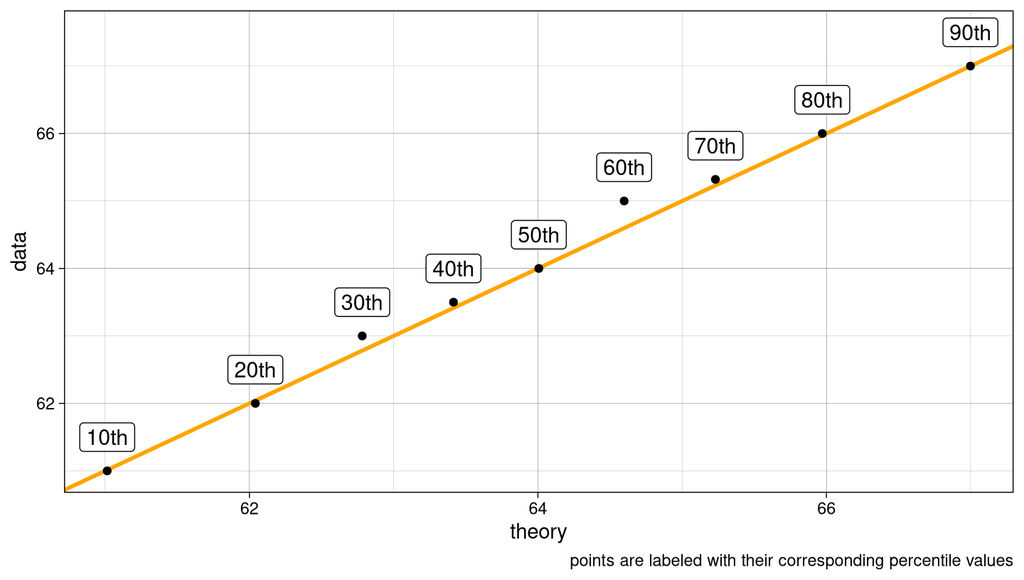

## Quantile-Quantile Plot (QQ Plot)

Do the quantiles of the data match the theoretical quantiles of a normal distribution with the same mean and variance?

```r
ggplot(parent_hts, aes(sample = Mother)) +
  stat_qq() +
  stat_qq_line(
    color = "orange",
    size = 1
  )
```

Notice in the aesthetics syntax, we use `sample =` rather than `x =` to indicate the variable to be plotted.

In the final plot, the x axis will be the theoretical quantiles on a standard normal curve, while the y axis is the quantiles from the data. There is a point representing each data value.

## Data vs. Theoretical

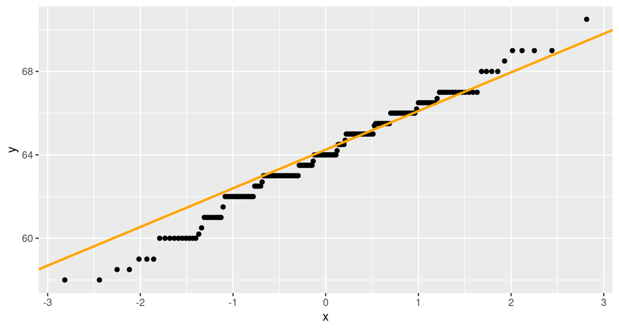

The theoretical axis (x-axis) is scaled to the standard normal distribution. The y-axis is scaled to the data.

## Questions

- How well does the data distribution match the straight line? Where does it it deviate?
- Is there a pattern to any data deviations from the theoretical normal curve, or do they appear to be random?
  - A U-shaped pattern usually indicates *skewness*
  - An S-shaped pattern suggests excess *kurtosis*
- Can you connect deviations in this plot to any you may have observed in the density plot?
- Significant skewness or large outliers should be detectable in and consistent across plots.

## Theoretical Skewness

Skewness quantifies the degree of asymmetry in a distribution. In general, for *unimodal* data:

- Skewness \(= 0\) ➔ the distribution is perfectly symmetric.
- Skewness \(< 0\) ➔ the distribution is left (negatively); the left tail is longer than the right tail.
- Skewness \(> 0\) ➔ the distribution is right (positively) skewed; the right tail is longer than the left tail.

The larger the deviation from zero, the stronger the skew.

We are unlikely to observe exactly zero skewness in real-world samples because of natural (random) variability in the sampling process, discretizing or rounding of the data values, etc.

## Sample Skewness Statistic

Some guidelines for interpreting skewness in samples.

| Value | Interpretation |
| --- | --- |
| less than -1 | the sample distribution is strongly left (negatively) skewed |
| -1 to -1/2 | the sample distribution is moderately left skewed |
| between ± 1/2 | the sample distribution is approximately symmetric |
| +1/2 to +1 | the sample distribution is moderately right skewed |
| greater than +1 | the sample distribution is strongly right (positively) skewed |

## Theoretical Kurtosis

Kurtosis quantifies how peaked and heavy-tailed a distribution is, compared to a normal distribution (kurtosis = 3).

We often use a measure called *excess* kurtosis, which subtracts 3 from the kurtosis measure. Excess kurtosis for the normal curve is 0 and ± values have a more intuitive interpretation.

In general, for *unimodal* data:

- Excess kurtosis \(= 0\) ➔ distribution has the kind of peak and tails we would expect in a bell shape (mesokurtic).
- Excess kurtosis \(< 0\) ➔ distribution is less peaked (flatter) and has shorter/thinner tails than a bell curve (platykurtic).
- Excess kurtosis \(> 0\) ➔ distribution is more peaked (sharper) and has fatter/thicker tails than a bell curve (leptokurtic).

## Sample Kurtosis Statistic

The [image](https://commons.wikimedia.org/wiki/File:Standard_symmetric_pdfs.svg) shows pdfs for a few distributions that have \(\mu = 0\) and \(\sigma = 1\) like the standard normal (middle curve, black). This gives you a sense of the differences in excess kurtosis among unimodal, symmetric distributions.

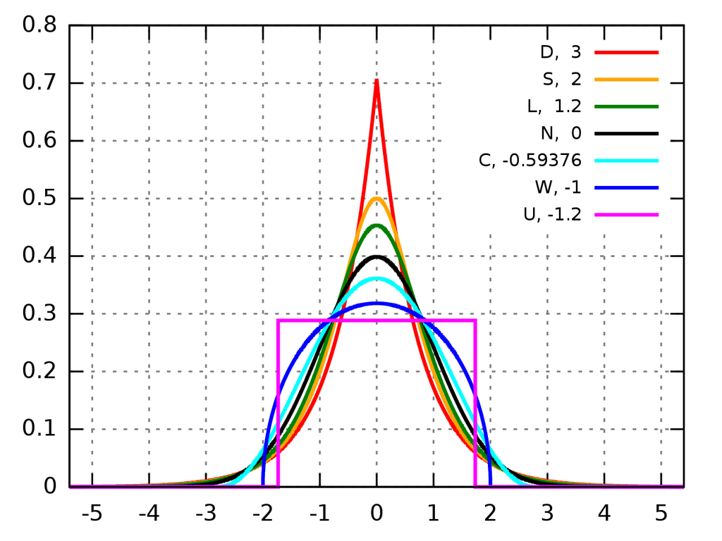

## Theory vs. Data

The skewness of a normal distribution is 0 and the kurtosis is 3. Data from a normal distribution should have similar values.

```r
library(moments)
tibble(statistic = c("Skewness", "Kurtosis", "Excess K"),
       theory    = c(0, 3, 0),
       data      = c(skewness(parent_hts$Mother),
                     kurtosis(parent_hts$Mother),
                     kurtosis(parent_hts$Mother) - 3))
```

```
# A tibble: 3 × 3
  statistic theory    data
  <chr>      <dbl>   <dbl>
1 Skewness       0 -0.185
2 Kurtosis       3  2.95
3 Excess K       0 -0.0523
```

## Other Data

Assess other Galton data for normality. For child heights, do the assessment with and without groups by gender. Was Quetelet right to think human height is normally distributed?

- galtonheightdata.csv (for child height data)

Some other interesting datasets are linked below.

- [`mileage`](https://raw.githubusercontent.com/STAT-JET-ASU/Datasets/master/Instructor/gasmileage.csv) : results of 100 EPA gas mileage tests for a particular model of car, in miles per gallon (mpg)
- [`geyser`](https://raw.githubusercontent.com/STAT-JET-ASU/Datasets/master/Instructor/oldfaithful.csv) : eruption data for Old Faithful geyser in Yellowstone National Park, including duration in minutes and number of minutes until the next eruption.
- [`wells`](https://raw.githubusercontent.com/STAT-JET-ASU/Datasets/master/Chihara/Bangladesh.csv) : concentration of three contaminants for a sample of wells in Bangladesh, in ppb or ppm